# Model-Human Alignment: Correlation, Accuracy, and Constraint Analysis

2026-03-05

## Overview

This analysis examines three complementary perspectives on how language models develop binomial ordering preferences during training:

1. **Correlation**: Pearson r between model preference and human preference at each checkpoint
2. **Accuracy**: Proportion of binomials where model and human agree on ordering direction (binary match)
3. **Constraint sensitivity**: How model preferences align with individual linguistic constraints (Form, Percept, Culture, etc.) and the composite GenPref measure

All analyses are conducted separately for **nonce** (novel) and **attested** (corpus-found) binomials.

## Load and Prepare Data

```r
# Load pre-processed data. Run prepare_data.py first if any file is missing.
# Constraint and GenPref regressions are fit below in R (see Analysis 3 & 4).
processed_path <- "../Data/processed"

csv_names <- c(
  "nonce_correlations", "attested_correlations",
  "nonce_accuracy",     "attested_accuracy",
  "final_nonce",        "final_attested",
  "training_nonce",     "training_attested"
)

missing <- csv_names[!file.exists(file.path(processed_path, paste0(csv_names, ".csv")))]
if (length(missing) > 0) {
  stop(sprintf(
    "Missing processed files: %s\nRun prepare_data.py first.",
    paste(missing, collapse = ", ")
  ))
}

for (nm in csv_names) {
  assign(nm, read_csv(file.path(processed_path, paste0(nm, ".csv")),
                      show_col_types = FALSE))
}

cat(sprintf("Nonce correlations:    %d rows\n",  nrow(nonce_correlations)))
```

```
## Nonce correlations:    5663 rows
```

```r
cat(sprintf("Attested correlations: %d rows\n",  nrow(attested_correlations)))
```

```
## Attested correlations: 5663 rows
```

```r
cat(sprintf("Final nonce data:      %d rows\n",  nrow(final_nonce)))
```

```
## Final nonce data:      786 rows
```

```r
cat(sprintf("Final attested data:   %d rows\n",  nrow(final_attested)))
```

```
## Final attested data:   3564 rows
```

```r
cat(sprintf("Training nonce:        %d rows (%d checkpoints)\n",
            nrow(training_nonce),    n_distinct(training_nonce$checkpoint)))
```

```
## Training nonce:        14934 rows (87 checkpoints)
```

```r
cat(sprintf("Training attested:     %d rows (%d checkpoints)\n",
            nrow(training_attested), n_distinct(training_attested$checkpoint)))
```

```
## Training attested:     67716 rows (87 checkpoints)
```

```r
# Fit OLS constraint regressions and GenPref regressions in R at the
# log-sampled checkpoints (stored in training_nonce / training_attested).

CONSTRAINT_COLS <- c("Form", "Percept", "Culture", "Power", "Intense",
                     "Icon", "Freq", "Len", "Lapse", "BStress")

fit_constraint_models_R <- function(data) {
  data %>%
    group_by(model, checkpoint, step, tokens) %>%
    group_map(function(g, keys) {
      complete <- g %>%
        select(preference, all_of(CONSTRAINT_COLS)) %>%
        drop_na()
      if (nrow(complete) < 15) return(NULL)
      fit <- lm(reformulate(CONSTRAINT_COLS, "preference"), data = complete)
      cf  <- coef(summary(fit))
      tibble(
        model      = keys$model,
        checkpoint = keys$checkpoint,
        step       = keys$step,
        tokens     = keys$tokens,
        constraint  = rownames(cf)[-1],
        coefficient = cf[-1, "Estimate"],
        se          = cf[-1, "Std. Error"],
        p_value     = cf[-1, "Pr(>|t|)"]
      )
    }, .keep = TRUE) %>%
    bind_rows()
}

fit_genpref_models_R <- function(data) {
  data %>%
    group_by(model, checkpoint, step, tokens) %>%
    group_map(function(g, keys) {
      complete <- g %>% select(preference, GenPref) %>% drop_na()
      if (nrow(complete) < 5) return(NULL)
      fit <- lm(preference ~ GenPref, data = complete)
      cf  <- coef(summary(fit))
      tibble(
        model      = keys$model,
        checkpoint = keys$checkpoint,
        step       = keys$step,
        tokens     = keys$tokens,
        coefficient = cf["GenPref", "Estimate"],
        se          = cf["GenPref", "Std. Error"],
        p_value     = cf["GenPref", "Pr(>|t|)"]
      )
    }, .keep = TRUE) %>%
    bind_rows()
}

cat("Fitting constraint models (nonce)...\n")
```

```
## Fitting constraint models (nonce)...
```

```r
nonce_constraints    <- fit_constraint_models_R(training_nonce)
cat("Fitting constraint models (attested)...\n")
```

```
## Fitting constraint models (attested)...
```

```r
attested_constraints <- fit_constraint_models_R(training_attested)

cat("Fitting GenPref models (nonce)...\n")
```

```
## Fitting GenPref models (nonce)...
```

```r
nonce_genpref    <- fit_genpref_models_R(training_nonce)
cat("Fitting GenPref models (attested)...\n")
```

```
## Fitting GenPref models (attested)...
```

```r
attested_genpref <- fit_genpref_models_R(training_attested)

cat(sprintf("Constraint results: nonce %d rows, attested %d rows\n",
            nrow(nonce_constraints), nrow(attested_constraints)))
```

```
## Constraint results: nonce 912 rows, attested 1140 rows
```

```r
cat(sprintf("GenPref results:    nonce %d rows, attested %d rows\n",
            nrow(nonce_genpref),    nrow(attested_genpref)))
```

```
## GenPref results:    nonce 114 rows, attested 114 rows
```

```r
# Consistent model ordering for all plots:
# BabyLM (125M → 350M → 1.3B) then C4 (125M → 350M → 1.3B)
MODEL_LEVELS <- c(
  "znhoughton/opt-babylm-125m-64eps-seed964",
  "znhoughton/opt-babylm-350m-64eps-seed964",
  "znhoughton/opt-babylm-1.3b-64eps-seed964",
  "znhoughton/opt-c4-125m-seed964",
  "znhoughton/opt-c4-350m-seed964",
  "znhoughton/opt-c4-1.3b-seed964"
)
MODEL_LABELS <- c(
  "BabyLM 125M", "BabyLM 350M", "BabyLM 1.3B",
  "C4 125M",     "C4 350M",     "C4 1.3B"
)
fct_model <- function(x) factor(x, levels = MODEL_LEVELS, labels = MODEL_LABELS)

CORPUS_COLORS <- c(
  "BabyLM 125M" = "#1b7837", "BabyLM 350M" = "#5aae61", "BabyLM 1.3B" = "#a6dba0",
  "C4 125M"     = "#762a83", "C4 350M"     = "#af8dc3", "C4 1.3B"     = "#e7d4e8"
)
```

## Analysis 1: Correlation Over Training

Compute Pearson r between model preference and human preference at each checkpoint.

```r
cat("\n=== FINAL CORRELATIONS ===\n\n")
```

```
##
## === FINAL CORRELATIONS ===
```

```r
cat("NONCE BINOMIALS:\n")
```

```
## NONCE BINOMIALS:
```

```r
nonce_correlations %>%
  group_by(model) %>%
  slice_max(tokens, n = 1) %>%
  select(model, tokens, correlation) %>%
  kable(digits = 3)
```

| model | tokens | correlation |
| --- | --- | --- |
| znhoughton/opt-babylm-1.3b-64eps-seed964 | 8965324800 | 0.195 |
| znhoughton/opt-babylm-125m-64eps-seed964 | 8965324800 | -0.033 |
| znhoughton/opt-babylm-350m-64eps-seed964 | 8965324800 | -0.003 |
| znhoughton/opt-c4-1.3b-seed964 | 9987686400 | -0.018 |
| znhoughton/opt-c4-125m-seed964 | 9987686400 | 0.031 |
| znhoughton/opt-c4-350m-seed964 | 9987686400 | -0.131 |

```r
cat("\nATTESTED BINOMIALS:\n")
```

```
##
## ATTESTED BINOMIALS:
```

```r
attested_correlations %>%
  group_by(model) %>%
  slice_max(tokens, n = 1) %>%
  select(model, tokens, correlation) %>%
  kable(digits = 3)
```

| model | tokens | correlation |
| --- | --- | --- |
| znhoughton/opt-babylm-1.3b-64eps-seed964 | 8965324800 | 0.472 |
| znhoughton/opt-babylm-125m-64eps-seed964 | 8965324800 | 0.587 |
| znhoughton/opt-babylm-350m-64eps-seed964 | 8965324800 | 0.447 |
| znhoughton/opt-c4-1.3b-seed964 | 9987686400 | 0.665 |
| znhoughton/opt-c4-125m-seed964 | 9987686400 | 0.677 |
| znhoughton/opt-c4-350m-seed964 | 9987686400 | 0.551 |

### Plot: Correlation Over Training

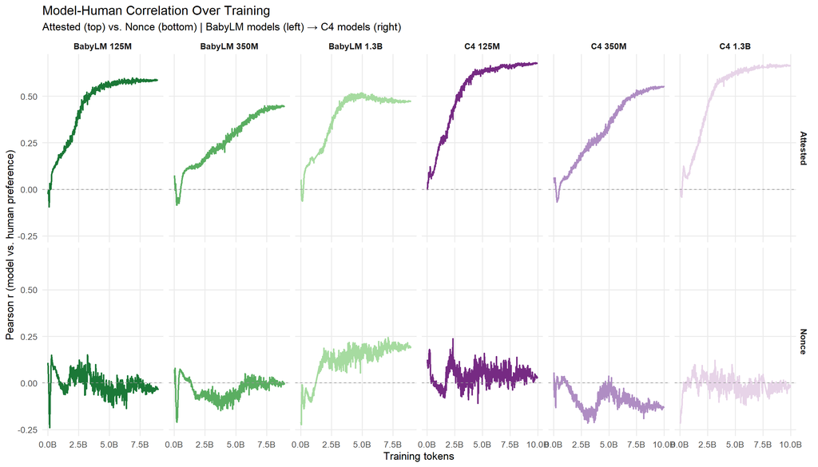

```r
bind_rows(
  nonce_correlations    %>% mutate(item_type = "Nonce"),
  attested_correlations %>% mutate(item_type = "Attested")
) %>%
  mutate(model = fct_model(model)) %>%
  ggplot(aes(x = tokens, y = correlation, color = model)) +
  geom_line(linewidth = 1) +
  geom_hline(yintercept = 0, linetype = "dashed", color = "gray60") +
  facet_grid(item_type ~ model, scales = "free_x") +
  scale_x_continuous(labels = scales::label_number(scale = 1e-9, suffix = "B")) +
  scale_color_manual(values = CORPUS_COLORS) +
  labs(
    x        = "Training tokens",
    y        = "Pearson r (model vs. human preference)",
    title    = "Model-Human Correlation Over Training",
    subtitle = "Attested (top) vs. Nonce (bottom) | BabyLM models (left) → C4 models (right)"
  ) +
  theme_minimal(base_size = 13) +
  theme(
    strip.text       = element_text(face = "bold"),
    legend.position  = "none",
    panel.grid.minor = element_blank()
  )
```

## Analysis 2: Accuracy Over Training

Accuracy = proportion of binomials where model and human agree on ordering direction.

- Model direction: mean preference > 0.5 (prefers alphabetical) vs. ≤ 0.5
- Human direction: hum_pref > 0.5 vs. ≤ 0.5
- Correct if both agree on direction

```r
cat("\n=== FINAL ACCURACIES ===\n\n")
```

```
##
## === FINAL ACCURACIES ===
```

```r
cat("NONCE BINOMIALS:\n")
```

```
## NONCE BINOMIALS:
```

```r
nonce_accuracy %>%
  group_by(model) %>%
  slice_max(tokens, n = 1) %>%
  select(model, tokens, accuracy) %>%
  kable(digits = 3)
```

| model | tokens | accuracy |
| --- | --- | --- |
| znhoughton/opt-babylm-1.3b-64eps-seed964 | 8965324800 | 0.542 |
| znhoughton/opt-babylm-125m-64eps-seed964 | 8965324800 | 0.481 |
| znhoughton/opt-babylm-350m-64eps-seed964 | 8965324800 | 0.489 |
| znhoughton/opt-c4-1.3b-seed964 | 9987686400 | 0.458 |
| znhoughton/opt-c4-125m-seed964 | 9987686400 | 0.511 |
| znhoughton/opt-c4-350m-seed964 | 9987686400 | 0.427 |

```r
cat("\nATTESTED BINOMIALS:\n")
```

```
##
## ATTESTED BINOMIALS:
```

```r
attested_accuracy %>%
  group_by(model) %>%
  slice_max(tokens, n = 1) %>%
  select(model, tokens, accuracy) %>%
  kable(digits = 3)
```

| model | tokens | accuracy |
| --- | --- | --- |
| znhoughton/opt-babylm-1.3b-64eps-seed964 | 8965324800 | 0.662 |
| znhoughton/opt-babylm-125m-64eps-seed964 | 8965324800 | 0.692 |
| znhoughton/opt-babylm-350m-64eps-seed964 | 8965324800 | 0.614 |
| znhoughton/opt-c4-1.3b-seed964 | 9987686400 | 0.685 |
| znhoughton/opt-c4-125m-seed964 | 9987686400 | 0.705 |
| znhoughton/opt-c4-350m-seed964 | 9987686400 | 0.680 |

### Plot: Accuracy Over Training

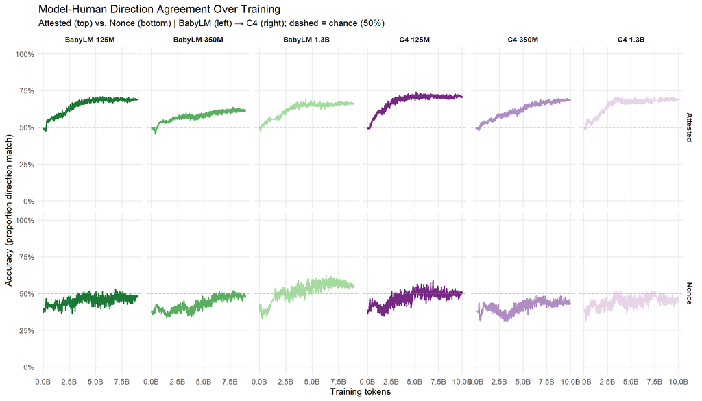

```r
bind_rows(
  nonce_accuracy    %>% mutate(item_type = "Nonce"),
  attested_accuracy %>% mutate(item_type = "Attested")
) %>%
  mutate(model = fct_model(model)) %>%
  ggplot(aes(x = tokens, y = accuracy, color = model)) +
  geom_line(linewidth = 1) +
  geom_hline(yintercept = 0.5, linetype = "dashed", color = "gray60") +
  facet_grid(item_type ~ model, scales = "free_x") +
  scale_x_continuous(labels = scales::label_number(scale = 1e-9, suffix = "B")) +
  scale_y_continuous(limits = c(0, 1), labels = scales::percent) +
  scale_color_manual(values = CORPUS_COLORS) +
  labs(
    x        = "Training tokens",
    y        = "Accuracy (proportion direction match)",
    title    = "Model-Human Direction Agreement Over Training",
    subtitle = "Attested (top) vs. Nonce (bottom) | BabyLM (left) → C4 (right); dashed = chance (50%)"
  ) +
  theme_minimal(base_size = 13) +
  theme(
    strip.text       = element_text(face = "bold"),
    legend.position  = "none",
    panel.grid.minor = element_blank()
  )
```

## Analysis 3: Individual Constraint Effects Over Training

For each checkpoint, fit: `lm(preference ~ Form + Percept + Culture + Power + Intense + Icon + Freq + Len + Lapse + BStress)`

```r
cat("\n=== FINAL CONSTRAINT COEFFICIENTS ===\n\n")
```

```
##
## === FINAL CONSTRAINT COEFFICIENTS ===
```

```r
cat("NONCE BINOMIALS (final checkpoint):\n")
```

```
## NONCE BINOMIALS (final checkpoint):
```

```r
nonce_constraints %>%
  group_by(model, constraint) %>%
  slice_max(tokens, n = 1) %>%
  select(model, constraint, coefficient) %>%
  pivot_wider(names_from = constraint, values_from = coefficient) %>%
  kable(digits = 3)
```

| model | BStress | Culture | Freq | Intense | Lapse | Len | Percept | Power |
| --- | --- | --- | --- | --- | --- | --- | --- | --- |
| znhoughton/opt-babylm-1.3b-64eps-seed964 | 0.676 | 1.166 | -0.033 | 0.576 | -0.843 | 0.216 | -0.111 | 0.285 |
| znhoughton/opt-babylm-125m-64eps-seed964 | -0.073 | 0.051 | 0.164 | -0.668 | 0.314 | -0.463 | 0.146 | 0.947 |
| znhoughton/opt-babylm-350m-64eps-seed964 | 0.363 | -0.228 | 0.102 | -0.431 | 0.040 | -0.198 | 0.516 | 0.332 |
| znhoughton/opt-c4-1.3b-seed964 | -0.027 | 0.261 | -0.061 | -0.079 | 0.043 | -0.152 | 0.140 | 0.194 |
| znhoughton/opt-c4-125m-seed964 | -0.135 | -0.013 | -0.009 | 0.261 | 0.021 | -0.051 | -0.101 | 0.075 |
| znhoughton/opt-c4-350m-seed964 | -0.596 | -0.308 | 0.048 | -0.202 | 1.092 | -0.238 | 0.101 | -0.084 |

```r
cat("\nATTESTED BINOMIALS (final checkpoint):\n")
```

```
##
## ATTESTED BINOMIALS (final checkpoint):
```

```r
attested_constraints %>%
  group_by(model, constraint) %>%
  slice_max(tokens, n = 1) %>%
  select(model, constraint, coefficient) %>%
  pivot_wider(names_from = constraint, values_from = coefficient) %>%
  kable(digits = 3)
```

| model | BStress | Culture | Form | Freq | Icon | Intense | Lapse | Len | Percept | Power |
| --- | --- | --- | --- | --- | --- | --- | --- | --- | --- | --- |
| znhoughton/opt-babylm-1.3b-64eps-seed964 | -0.279 | 0.926 | 0.652 | 0.155 | 1.536 | 0.217 | 0.146 | 0.203 | 0.502 | 0.758 |
| znhoughton/opt-babylm-125m-64eps-seed964 | 0.116 | 0.766 | 0.637 | 0.284 | 1.357 | 0.080 | -0.041 | 0.179 | 0.310 | 1.158 |
| znhoughton/opt-babylm-350m-64eps-seed964 | 0.220 | 0.366 | 0.479 | -0.003 | 0.602 | 0.152 | -0.012 | 0.004 | 0.215 | 0.885 |
| znhoughton/opt-c4-1.3b-seed964 | 0.377 | 0.707 | 0.438 | 0.135 | 1.741 | 0.363 | -0.153 | 0.270 | 0.507 | 0.715 |
| znhoughton/opt-c4-125m-seed964 | 0.219 | 0.805 | 0.335 | 0.095 | 1.505 | 0.397 | -0.071 | 0.302 | 0.487 | 0.789 |
| znhoughton/opt-c4-350m-seed964 | 0.225 | 0.518 | 0.272 | 0.062 | 1.189 | 0.631 | -0.043 | 0.164 | 0.322 | 0.542 |

### Plot: Individual Constraint Coefficients Over Training (Nonce)

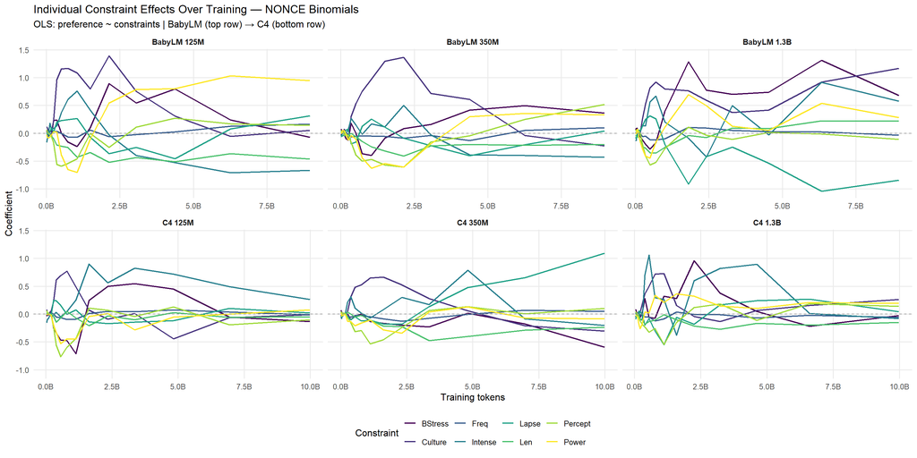

```r
nonce_constraints %>%
  mutate(model = fct_model(model)) %>%
  ggplot(aes(x = tokens, y = coefficient, color = constraint)) +
  geom_line(linewidth = 0.8) +
  geom_hline(yintercept = 0, linetype = "dashed", color = "gray60") +
  facet_wrap(~ model, scales = "free_x", ncol = 3) +
  scale_x_continuous(labels = scales::label_number(scale = 1e-9, suffix = "B")) +
  scale_color_viridis_d() +
  labs(
    x        = "Training tokens",
    y        = "Coefficient",
    title    = "Individual Constraint Effects Over Training — NONCE Binomials",
    subtitle = "OLS: preference ~ constraints | BabyLM (top row) → C4 (bottom row)",
    color    = "Constraint"
  ) +
  theme_minimal(base_size = 12) +
  theme(
    strip.text       = element_text(face = "bold"),
    panel.grid.minor = element_blank(),
    legend.position  = "bottom"
  ) +
  guides(color = guide_legend(nrow = 2))
```

### Plot: Individual Constraint Coefficients Over Training (Attested)

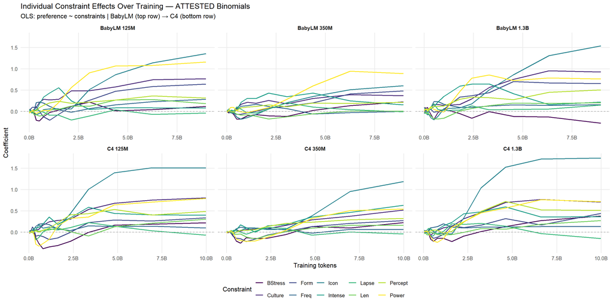

```r
attested_constraints %>%
  mutate(model = fct_model(model)) %>%
  ggplot(aes(x = tokens, y = coefficient, color = constraint)) +
  geom_line(linewidth = 0.8) +
  geom_hline(yintercept = 0, linetype = "dashed", color = "gray60") +
  facet_wrap(~ model, scales = "free_x", ncol = 3) +
  scale_x_continuous(labels = scales::label_number(scale = 1e-9, suffix = "B")) +
  scale_color_viridis_d() +
  labs(
    x        = "Training tokens",
    y        = "Coefficient",
    title    = "Individual Constraint Effects Over Training — ATTESTED Binomials",
    subtitle = "OLS: preference ~ constraints | BabyLM (top row) → C4 (bottom row)",
    color    = "Constraint"
  ) +
  theme_minimal(base_size = 12) +
  theme(
    strip.text       = element_text(face = "bold"),
    panel.grid.minor = element_blank(),
    legend.position  = "bottom"
  ) +
  guides(color = guide_legend(nrow = 2))
```

## Analysis 4: GenPref Effect Over Training

Fit `lm(preference ~ GenPref)` at each checkpoint to track overall sensitivity to the composite measure.

```r
cat("\n=== FINAL GENPREF COEFFICIENTS ===\n\n")
```

```
##
## === FINAL GENPREF COEFFICIENTS ===
```

```r
cat("NONCE BINOMIALS:\n")
```

```
## NONCE BINOMIALS:
```

```r
nonce_genpref %>%
  group_by(model) %>%
  slice_max(tokens, n = 1) %>%
  select(model, tokens, coefficient) %>%
  kable(digits = 3)
```

| model | tokens | coefficient |
| --- | --- | --- |
| znhoughton/opt-babylm-1.3b-64eps-seed964 | 8965324800 | 4.735 |
| znhoughton/opt-babylm-125m-64eps-seed964 | 8965324800 | 3.295 |
| znhoughton/opt-babylm-350m-64eps-seed964 | 8965324800 | 2.086 |
| znhoughton/opt-c4-1.3b-seed964 | 9987686400 | 0.706 |
| znhoughton/opt-c4-125m-seed964 | 9987686400 | -0.428 |
| znhoughton/opt-c4-350m-seed964 | 9987686400 | -0.399 |

```r
cat("\nATTESTED BINOMIALS:\n")
```

```
##
## ATTESTED BINOMIALS:
```

```r
attested_genpref %>%
  group_by(model) %>%
  slice_max(tokens, n = 1) %>%
  select(model, tokens, coefficient) %>%
  kable(digits = 3)
```

| model | tokens | coefficient |
| --- | --- | --- |
| znhoughton/opt-babylm-1.3b-64eps-seed964 | 8965324800 | 6.282 |
| znhoughton/opt-babylm-125m-64eps-seed964 | 8965324800 | 6.586 |
| znhoughton/opt-babylm-350m-64eps-seed964 | 8965324800 | 2.665 |
| znhoughton/opt-c4-1.3b-seed964 | 9987686400 | 7.020 |
| znhoughton/opt-c4-125m-seed964 | 9987686400 | 6.535 |
| znhoughton/opt-c4-350m-seed964 | 9987686400 | 4.672 |